# DELE CA2 Part B

**Name: Law Wei Tin (2415761) and Liu Xingyu (2415451)**  
**Class: DAAA/FT/2A/02**

# Background Research

A classic control benchmark is the inverted pendulum: a rigid rod hinged at one end, free to rotate 360 °.

The task in Pendulum‑v0 (OpenAI Gym) is to:

- swing the pendulum up from its natural resting position (hanging down) and
- keep it balanced as close to vertical as possible,
- while minimising control effort (torque).

Problem Definition

- **State**: a 3D vector: `[cos(theta), sin(theta), theta_dot]`
- **Action**: a continuous torque value in the range `[-2, 2]` (Nm)
- **Reward**: at each step, `reward = -(theta^2 + 0.1 * theta_dot^2 + 0.001 * torque^2)`

This makes the task a **continuous control** problem, with a trade-off between stability and energy efficiency.

Because the system is continuous, nonlinear, and underactuated, traditional control methods (like PID) may not suffice — making it an ideal use case for **Reinforcement Learning (RL)**.

However, traditional **Deep Q-Networks (DQNs)** are designed for **discrete action space**s, while Pendulum’s **action space is continuous**. Therefore, to apply DQN to this problem, **we discretize the continuous action space** into a fixed number of evenly spaced torque values.

To improve learning stability and performance, we explore variants of DQN:

- **Double DQN**: Reduces overestimation bias in Q-values.
- **Dueling DQN**: Separates value estimation and advantage estimation, improving learning in environments with similar-valued actions.
- **PER DQN (Prioritized Experience Replay)**: Prioritizes learning from important transitions, those with high TD error, improving sample efficiency and convergence speed.

However, while each individual DQN enhancement provides specific benefits, **combining them can lead to a more robust agent**. **Rainbow DQN** integrates several key improvements into a single architecture, **Double DQN, Dueling DQN, Prioritized Experience Replay (PER)**

# Importing Libraries

```python
!pip install gym==0.17.3 --quiet
```

[output not shown]

```python
!pip install keras-tuner --quiet
```

```python
import shutil
import os
import gym
import random

import numpy as np
import pandas as pd
import matplotlib.pyplot as plt

import tensorflow as tf
from tensorflow.keras.models import Sequential, Model
from tensorflow.keras.layers import Input, Dense, Lambda, Add, Subtract
from tensorflow.keras.optimizers import Adam

from collections import deque
```

[output not shown]

```python
print(gym.__version__)
```

```
0.17.3
```

## Setting up video rendering in Kaggle

- We have to do some configurations as Video Rendering is not directly compatible in Kaggle

```python
!apt-get update > /dev/null
!apt-get install -y xvfb python3-opengl ffmpeg > /dev/null

!pip install pyglet==1.5.27 Pillow==9.4.0 > /dev/null
```

[output not shown]

```python
# Set up virtual display (headless)
os.system("Xvfb :1 -screen 0 1400x900x24 &")
os.environ["DISPLAY"] = ":1"
```

```python
import pyglet
from pyglet.image.codecs import pil

# Patch the decoder to avoid using removed "tostring"
def decode_fixed(self, file, filename):
    from PIL import Image as PILImage
    image = PILImage.open(file)
    width, height = image.size
    image_data = image.tobytes()
    return pyglet.image.ImageData(width, height, image.mode, image_data)

# Override the broken method
pil.PILImageDecoder.decode = decode_fixed
```

# Exploratory Data Analysis

```python
env = gym.make('Pendulum-v0')

print("Observation space:", env.observation_space)
print("Observation high:", env.observation_space.high)
print("Observation low:", env.observation_space.low)
print("Action space:", env.action_space)
print("Action high:", env.action_space.high)
print("Action low:", env.action_space.low)
```

```
Observation space: Box(-8.0, 8.0, (3,), float32)
Observation high: [1. 1. 8.]
Observation low: [-1. -1. -8.]
Action space: Box(-2.0, 2.0, (1,), float32)
Action high: [2.]
Action low: [-2.]
```

The Pendulum-v0 environment simulates a frictionless pendulum where the goal is to keep it upright by applying torque.

The observation space is a 3-dimensional continuous space:

- **cos(θ)**: cosine of the pendulum angle
- **sin(θ)**: sine of the pendulum angle
- **θ̇:** angular velocity

The action space is a **continuous range** of torque values from **−2 to 2.**

## Discretising the action space

Deep Q-Networks (DQNs) are designed for environments with discrete action spaces. Since Pendulum-v0 has a continuous action space, we must discretise it before applying DQN.

For example, we can discretise the torque values into fixed bins, such as:

```python
# Discretize action space
discrete_actions = np.linspace(-2, 2, 11)
```

```python
discrete_actions
```

```
array([-2. , -1.6, -1.2, -0.8, -0.4,  0. ,  0.4,  0.8,  1.2,  1.6,  2. ])
```

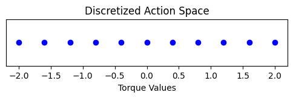

```python
plt.figure(figsize=(6, 1))
plt.scatter(discrete_actions, [1]*len(discrete_actions), c='blue')
plt.yticks([])
plt.title("Discretized Action Space")
plt.xlabel("Torque Values")
plt.show()
```

## Random Rollouts and State Tracking

To understand how the environment behaves with no learning (i.e., random actions), we observe the state transitions and rewards over time.

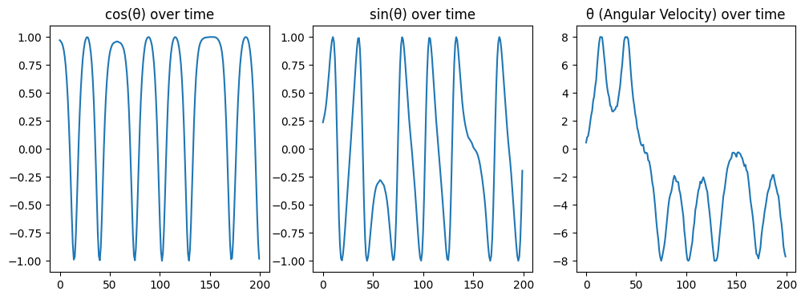

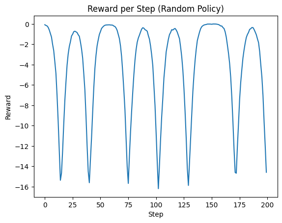

```python
obs_list, reward_list = [], []

obs = env.reset()
for _ in range(200):
    obs_list.append(obs)
    action = env.action_space.sample()
    obs, reward, done, _ = env.step(action)
    reward_list.append(reward)

obs_array = np.array(obs_list)

plt.figure(figsize=(12, 4))
plt.subplot(1, 3, 1)
plt.plot(obs_array[:, 0])
plt.title("cos(θ) over time")
plt.subplot(1, 3, 2)
plt.plot(obs_array[:, 1])
plt.title("sin(θ) over time")
plt.subplot(1, 3, 3)
plt.plot(obs_array[:, 2])
plt.title("θ̇ (Angular Velocity) over time")
plt.show()

plt.figure()
plt.plot(reward_list)
plt.title("Reward per Step (Random Policy)")
plt.xlabel("Step")
plt.ylabel("Reward")
plt.show()
```

- When actions are sampled randomly, the pendulum shows chaotic behaviour, and its angle and velocity oscillate without stabilising.
- The reward per step fluctuates significantly, staying largely negative and unstable.
- This shows that a random policy will not be able to keep the pendulum upright

## Reward Heatmap by State

We now visualize how rewards change based on angle and angular velocity, assuming zero torque.

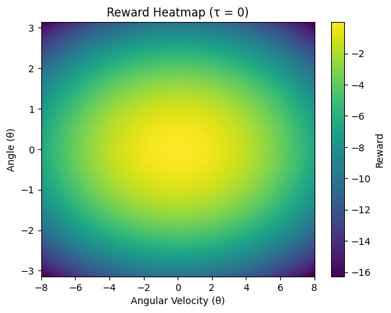

```python
theta_vals = np.linspace(-np.pi, np.pi, 100)
theta_dot_vals = np.linspace(-8, 8, 100)
rewards = np.zeros((len(theta_vals), len(theta_dot_vals)))

for i, theta in enumerate(theta_vals):
    for j, theta_dot in enumerate(theta_dot_vals):
        reward = -(theta**2 + 0.1 * theta_dot**2 + 0.001 * (0)**2)  # zero torque
        rewards[i, j] = reward

plt.imshow(rewards, extent=[-8, 8, -np.pi, np.pi], origin='lower', aspect='auto', cmap='viridis')
plt.colorbar(label="Reward")
plt.xlabel("Angular Velocity (θ̇)")
plt.ylabel("Angle (θ)")
plt.title("Reward Heatmap (τ = 0)")
plt.show()
```

- The heatmap shows the reward landscape for different angles (θ) and angular velocities (θ̇), assuming no torque is applied.
- Lowest rewards occur when the pendulum is far from the upright position (θ ≠ 0) and moving quickly (high θ̇).
- The highest rewards are near the center (θ ≈ 0, θ̇ ≈ 0), where the pendulum is upright and still.
- This helps confirm that the optimal policy must minimize both deviation from upright and angular velocity.

## Discretized State Distribution Under Random Policy

To better understand how the agent explores the state space under a random policy, we use PCA to project high-dimensional observations into 2D.

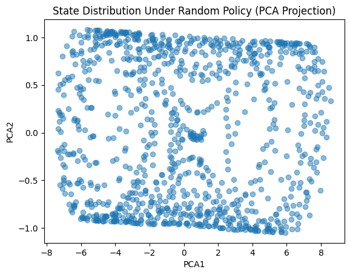

```python
from sklearn.decomposition import PCA

# Collect 1000 states
states = []
env.reset()
for _ in range(1000):
    action = env.action_space.sample()
    obs, reward, done, _ = env.step(action)
    states.append(obs)
    if done:
        env.reset()

states = np.array(states)

pca = PCA(n_components=2)
states_2d = pca.fit_transform(states)

plt.scatter(states_2d[:, 0], states_2d[:, 1], alpha=0.5)
plt.title("State Distribution Under Random Policy (PCA Projection)")
plt.xlabel("PCA1")
plt.ylabel("PCA2")
plt.show()
```

- The PCA projection reveals that the random policy results in wide and unfocused exploration of the state space.
- The distribution forms a dense cloud, showing the agent visits a broad range of states without any clear objective.
- There's no evident clustering, confirming the lack of learning or structure in state transitions.

# Model Building

We chose to apply Deep Q-Learning because of its effectiveness in solving value-based reinforcement learning tasks, especially when combined with improvements like experience replay and target networks.

Why DQN is Applicable By discretizing the action space, the environment becomes suitable for Q-learning-based agents. This transforms the problem into a form compatible with DQN, which can learn the expected future rewards of state-action pairs.

How the **DQN Learning Loop Works**:

1. The agent observes the **current state.**
2. It selects an **action** using an **ε-greedy policy.**
3. It performs the action and observes the reward and next state.
4. This experience **(state, action, reward, next_state, done)** is stored in the replay buffer.
5. Periodically, random **minibatches are sampled** from the buffer to train the model using the **Bellman update.**
6. The target network is **updated every few steps** to provide stable Q-value targets.

Why **Replay Memory and Target Networks**

- **Replay memory** helps avoid learning from highly correlated sequences of states by sampling experiences randomly.
- **Target networks** stabilize training by decoupling the target Q-value calculation from the model being updated.

Why **those hyperparameters**

- **n_actions = 11**: We discretize the continuous action space into 11 values for compatibility. It is also a common n_action for this problem
- **gamma = 0.99**: We prioritize long-term rewards to ensure stable control behavior.
- **lr = 1e-3**: We use a moderate learning rate for stable and reasonably fast training.
- **epsilon = 1.0**: We start with full exploration to encourage diverse experience collection.
- **epsilon_min = 0.01**: We ensure the agent continues exploring slightly at the end of training.
- **epsilon_decay = 0.995**: We gradually reduce exploration to favor exploitation over time.
- **batch_size = 64**: We balance gradient stability and training speed with this batch size.
- **replay_every = 4**: We update the model every 4 steps to reduce sample correlation and compute load.
- **replay_capacity = 100000**: We store a large variety of past experiences to improve learning diversity.
- **hidden_sizes = (64, 64)**: We use a small, efficient network to learn the Q-values effectively. 64 by 64 is sufficient for this problem according to common uses.
- **target_update_freq = 1000**: We sync the target network every 1000 steps to stabilize training.
- We can always tune these hyperparameters later on. These just gives us a good starting point.

## Base DQN

```python
class DQNPendulum:
    def __init__(self, env_name="Pendulum-v0", batch_size=64, replay_every=4, model_name="Base_DQN"):
        # ------------ Hyperparameters ------------------------------------ #
        self.n_actions        = 11
        self.gamma            = 0.99
        self.lr               = 1e-3
        self.epsilon          = 1.0
        self.epsilon_min      = 0.01
        self.epsilon_decay    = 0.995
        self.batch_size       = batch_size
        self.replay_every     = replay_every
        self.replay_capacity  = 100_000
        self.hidden_sizes     = (64, 64)
        self.target_update_freq = 1000
        self.model_name       = model_name

        # ------------ Environment ---------------------------------------- #
        self.env = gym.make(env_name)
        self.state_dim = self.env.observation_space.shape[0]
        self.discrete_actions = np.linspace(
            self.env.action_space.low[0],
            self.env.action_space.high[0],
            self.n_actions,
            dtype=np.float32,
        )

        # ------------ Internal State ------------------------------------- #
        self.memory         = deque(maxlen=self.replay_capacity)
        self.step_count     = 0

        self.best_avg_reward = -np.inf
        self.patience       = 100
        self.patience_counter = 0

        # ------------ Create Q-Networks --------------------------------- #
        self.model = self._build_model()
        self.target_model = self._build_model()
        self.update_target_network()
        self.optimizer = Adam(learning_rate=self.lr)

        # ------------ GPU Info ------------------------------------------ #
        print(f"[{model_name}] GPU available:", tf.config.list_physical_devices('GPU'))

    def _build_model(self):
        inputs = Input(shape=(self.state_dim,))
        x = Dense(self.hidden_sizes[0], activation="relu")(inputs)
        for h in self.hidden_sizes[1:]:
            x = Dense(h, activation="relu")(x)
        outputs = Dense(self.n_actions, activation="linear")(x)
        model = Model(inputs, outputs)
        return model

    def update_target_network(self):
        self.target_model.set_weights(self.model.get_weights())

    def act(self, state: np.ndarray) -> int:
        if np.random.rand() < self.epsilon:
            return np.random.randint(self.n_actions)
        q_values = self.model(state[np.newaxis, :], training=False).numpy()[0]
        return int(np.argmax(q_values))

    def remember(self, state, action_idx, reward, next_state, done):
        self.memory.append((state, action_idx, reward, next_state, done))

    @tf.function
    def train_step_with_gradient_tape(self, states, actions, target_q_values):
        with tf.GradientTape() as tape:
            q_values = self.model(states, training=True)
            one_hot_actions = tf.one_hot(actions, self.n_actions)
            chosen_q = tf.reduce_sum(q_values * one_hot_actions, axis=1)
            loss = tf.reduce_mean(tf.square(target_q_values - chosen_q))  # MSE loss
        grads = tape.gradient(loss, self.model.trainable_variables)
        self.optimizer.apply_gradients(zip(grads, self.model.trainable_variables))


    def replay(self):
        if len(self.memory) < self.batch_size:
            return

        batch = random.sample(self.memory, self.batch_size)
        states_batch = np.array([b[0] for b in batch], dtype=np.float32)
        actions_batch = np.array([b[1] for b in batch])
        rewards_batch = np.array([b[2] for b in batch], dtype=np.float32)
        next_states_batch = np.array([b[3] for b in batch], dtype=np.float32)
        dones_batch = np.array([b[4] for b in batch], dtype=np.float32)

        current_q = self.model(states_batch, training=False).numpy()
        next_q = self.target_model(next_states_batch, training=False).numpy()

        target_q_values = np.zeros(self.batch_size, dtype=np.float32)

        for i in range(self.batch_size):
            if dones_batch[i]:
                target_q_values[i] = rewards_batch[i]
            else:
                target_q_values[i] = rewards_batch[i] + self.gamma * np.max(next_q[i])

        self.train_step_with_gradient_tape(states_batch, actions_batch, target_q_values)

    def preprocess_state(self, state):
        if hasattr(state, '__len__') and len(state) == 1:
            state = state[0]
        return np.array(state, dtype=np.float32)
```

## Double DQN

**Why**: Traditional DQN tends to overestimate Q-values, especially in noisy environments.

**How**: Double DQN decouples the action selection and target evaluation by using the main network to select the best action and the target network to evaluate its value.

**Benefit**: We reduce value overestimation and encourage more stable learning, especially over long episodes.

```python
class DoubleDQNPendulum(DQNPendulum):
    def __init__(self, **kwargs):
        super().__init__(**kwargs)

    def replay(self):
        if len(self.memory) < self.batch_size:
            return

        batch = random.sample(self.memory, self.batch_size)
        states_batch = np.array([b[0] for b in batch])
        actions_batch = np.array([b[1] for b in batch])
        rewards_batch = np.array([b[2] for b in batch])
        next_states_batch = np.array([b[3] for b in batch])
        dones_batch = np.array([b[4] for b in batch])

        current_q = self.model(states_batch, training=False).numpy()
        next_q_main = self.model(next_states_batch, training=False).numpy()
        next_q_target = self.target_model(next_states_batch, training=False).numpy()

        next_actions = np.argmax(next_q_main, axis=1)

        target_q_values = np.zeros(self.batch_size, dtype=np.float32)

        for i in range(self.batch_size):
            if dones_batch[i]:
                target_q_values[i] = rewards_batch[i]
            else:
                target_q_values[i] = rewards_batch[i] + self.gamma * next_q_target[i][next_actions[i]]

        # Now train with correct scalar targets per action
        self.train_step_with_gradient_tape(states_batch, actions_batch, target_q_values)
```

## Dueling DQN

**Why**: In many states, the choice of action has little effect on the outcome.

**How**: Dueling DQN splits the network into two streams: one estimates the state value and the other estimates the advantage of each action.

**Benefit**: The agent learns which states are valuable, even when it's unsure about the best action — improving learning in environments with similar-valued actions.

```python
class DuelingDQNPendulum(DQNPendulum):
    def __init__(self, **kwargs):
        super().__init__(**kwargs)

    def _build_model(self):
        inputs = Input(shape=(self.state_dim,))
        x = Dense(self.hidden_sizes[0], activation="relu")(inputs)
        x = Dense(self.hidden_sizes[1], activation="relu")(x)

        # Value and Advantage streams
        value = Dense(1, activation=None)(x)  # V(s)
        advantage = Dense(self.n_actions, activation=None)(x)  # A(s,a)

        # Combine: Q(s,a) = V(s) + (A(s,a) - mean(A))
        advantage_mean = Lambda(lambda a: tf.reduce_mean(a, axis=1, keepdims=True))(advantage)
        q_values = Add()([value, Subtract()([advantage, advantage_mean])])

        model = Model(inputs=inputs, outputs=q_values)
        return model
```

## Prioritized Experience Replay DQN

**Why**: In uniform replay, all transitions are treated equally, even though some are more useful to learn from.

**How**: We prioritize transitions with higher TD error, increasing the sampling probability of experiences that the agent learns most from.

**Benefit**: This leads to faster and more efficient learning, especially in tasks where important transitions are rare or delayed.

```python
class PrioritizedReplayBuffer:
    def __init__(self, capacity, alpha=0.6):
        self.capacity = capacity
        self.alpha = alpha
        self.memory = []
        self.priorities = []
        self.pos = 0

    def add(self, transition, td_error=1.0):
        priority = (abs(td_error) + 1e-5) ** self.alpha
        if len(self.memory) < self.capacity:
            self.memory.append(transition)
            self.priorities.append(priority)
        else:
            self.memory[self.pos] = transition
            self.priorities[self.pos] = priority
            self.pos = (self.pos + 1) % self.capacity

    def sample(self, batch_size, beta=0.4):
        if len(self.memory) == 0:
            return [], [], []

        priorities = np.array(self.priorities)
        probs = priorities / priorities.sum()

        indices = np.random.choice(len(self.memory), batch_size, p=probs)
        samples = [self.memory[i] for i in indices]

        weights = (len(self.memory) * probs[indices]) ** (-beta)
        weights /= weights.max()

        return samples, indices, weights

    def update_priorities(self, indices, td_errors):
        for i, td in zip(indices, td_errors):
            self.priorities[i] = (abs(td) + 1e-5) ** self.alpha
```

```python
class PERDQNPendulum(DQNPendulum):
    def __init__(self, alpha=0.6, beta=0.4, **kwargs):
        super().__init__(model_name="PER_DQN", **kwargs)
        self.memory = PrioritizedReplayBuffer(self.replay_capacity, alpha)
        self.beta = beta

    def remember(self, state, action_idx, reward, next_state, done):
        self.memory.add((state, action_idx, reward, next_state, done))

    def replay(self):
        if len(self.memory.memory) < self.batch_size:
            return

        batch, indices, weights = self.memory.sample(self.batch_size, self.beta)
        states = np.array([b[0] for b in batch], dtype=np.float32)
        actions = np.array([b[1] for b in batch])
        rewards = np.array([b[2] for b in batch], dtype=np.float32)
        next_states = np.array([b[3] for b in batch], dtype=np.float32)
        dones = np.array([b[4] for b in batch], dtype=np.float32)

        current_q = self.model(states, training=False).numpy()
        next_q = self.target_model(next_states, training=False).numpy()

        target_q_values = np.zeros(self.batch_size, dtype=np.float32)
        td_errors = []

        for i in range(self.batch_size):
            target = rewards[i] if dones[i] else rewards[i] + self.gamma * np.max(next_q[i])
            td_error = target - current_q[i][actions[i]]
            td_errors.append(td_error)
            target_q_values[i] = target

        self.memory.update_priorities(indices, td_errors)

        self.train_step_with_gradient_tape(states, actions, target_q_values)
```

## MiniRainbow DQN

**Why**: Different DQN variants address different weaknesses — overestimation, sample inefficiency, and poor value estimation. By combining them, we get a stronger agent overall.

**How**: Rainbow DQN integrates:

- Double DQN to reduce overestimated Q-values,
- Dueling architecture to separately estimate state values and action advantages, and
- Prioritized Experience Replay (PER) to train more frequently on transitions with higher learning potential.

```python
class MiniRainbowDQNPendulum(DQNPendulum):
    def __init__(self, alpha=0.6, beta=0.4, **kwargs):
        super().__init__(model_name="Mini_Rainbow_DQN", **kwargs)
        self.memory = PrioritizedReplayBuffer(self.replay_capacity, alpha)
        self.beta = beta

    def _build_model(self):
        inputs = Input(shape=(self.state_dim,))
        x = Dense(self.hidden_sizes[0], activation="relu")(inputs)
        x = Dense(self.hidden_sizes[1], activation="relu")(x)

        value = Dense(1, activation=None)(x)
        advantage = Dense(self.n_actions, activation=None)(x)
        advantage_mean = Lambda(lambda a: tf.reduce_mean(a, axis=1, keepdims=True))(advantage)
        q_values = Add()([value, Subtract()([advantage, advantage_mean])])

        return Model(inputs, q_values)

    def remember(self, state, action_idx, reward, next_state, done):
        self.memory.add((state, action_idx, reward, next_state, done))

    def replay(self):
        if len(self.memory.memory) < self.batch_size:
            return

        batch, indices, weights = self.memory.sample(self.batch_size, self.beta)
        states = np.array([b[0] for b in batch], dtype=np.float32)
        actions = np.array([b[1] for b in batch])
        rewards = np.array([b[2] for b in batch], dtype=np.float32)
        next_states = np.array([b[3] for b in batch], dtype=np.float32)
        dones = np.array([b[4] for b in batch], dtype=np.float32)

        current_q = self.model(states, training=False).numpy()
        next_q_main = self.model(next_states, training=False).numpy()
        next_q_target = self.target_model(next_states, training=False).numpy()

        next_actions = np.argmax(next_q_main, axis=1)

        target_q_values = np.zeros(self.batch_size, dtype=np.float32)
        td_errors = []

        for i in range(self.batch_size):
            if dones[i]:
                target = rewards[i]
            else:
                target = rewards[i] + self.gamma * next_q_target[i][next_actions[i]]
            td_error = target - current_q[i][actions[i]]
            td_errors.append(td_error)
            target_q_values[i] = target

        self.memory.update_priorities(indices, td_errors)

        self.train_step_with_gradient_tape(states, actions, target_q_values)
```

# Model Training

To ensure a fair and structured comparison, we apply the same training pipeline to all five DQN-based models.

**Training Procedure** We define a training function that performs the following:

- Resets the environment at the start of each episode.
- At each step:
  - Selects an action using an ε-greedy policy.
  - Applies the action to the environment and collects the next state and reward.
  - Stores the transition into the replay buffer.
  - Periodically samples from the buffer to update the Q-network.
  - Updates the target network at fixed intervals.
- Decays the exploration rate epsilon over time.
- Tracks the reward per episode and uses it to monitor learning performance.

**Reward Normalization**

We use two plots to visualize learning progress:

1. Episode Rewards: Raw rewards for each episode to show variance and general trend.
2. Moving Average: Smoothened reward curve (window = 20 episodes) for easier comparison between models.

These plots help us judge:

- How quickly the agent learns.
- Stability of training.
- Consistency across episodes.

**Model Evaluation** After training, we evaluate each agent’s performance over multiple episodes using a greedy policy (ε = 0) to test what the model has learned.

- We run 10 test episodes per model.
- The rewards are averaged and standard deviation is computed to reflect stability and reliability.

This gives a good indication of how well the agent has generalized. ____ **Saving Metrics for Comparison**

After testing, we store the following performance metrics for each model into a summary table:

- Final training reward
- Average reward over last 20 training episodes
- Best and worst training reward
- Mean and standard deviation of test rewards
- Best and worst test rewards

**Saving the Best Model**

The best-performing model (based on average test reward or other selected metric) has its weights saved for future use or demo purposes.

```python
model_results = []
```

- We defined 'model_results' as we will be appending all the rewards of the different agents
- Then we will be evaluating them to fiind out which is the best model

## Functions for the agent

```python
# Function to train the agent
def train_dqn_agent(agent, episodes=500, render_every=0, max_steps=200, early_stop_reward=-200):
    rewards_history = []

    # Training for specified episodes
    for episode in range(episodes):
        state = agent.preprocess_state(agent.env.reset())
        episode_reward = 0.0

        for _ in range(max_steps):
            if render_every and episode % render_every == 0:
                try:
                    agent.env.render()
                except:
                    pass

            action_idx = agent.act(state)
            action = np.array([agent.discrete_actions[action_idx]], dtype=np.float32)
            next_state, reward, done, _ = agent.env.step(action)
            next_state = agent.preprocess_state(next_state)

            shaped_reward = reward / 16.27
            agent.remember(state, action_idx, shaped_reward, next_state, done)
            state = next_state
            episode_reward += reward

            if agent.step_count % agent.replay_every == 0:
                agent.replay()
            if agent.step_count % agent.target_update_freq == 0:
                agent.update_target_network()

            agent.step_count += 1

            if done:
                break

        # Decaying epsilon
        agent.epsilon = max(agent.epsilon_min, agent.epsilon_decay * agent.epsilon)

        # Adding episode reward to reward history
        rewards_history.append(episode_reward)

        if episode % 20 == 0:
            avg = np.mean(rewards_history[-20:])
            print(f"[{agent.model_name}] Ep {episode:03d} | Reward: {episode_reward:8.2f} | Avg: {avg:8.2f} | Epsilon: {agent.epsilon:.4f}")

        if len(rewards_history) >= 20:
            avg_reward = np.mean(rewards_history[-20:])
            if avg_reward > agent.best_avg_reward:
                agent.best_avg_reward = avg_reward
                agent.patience_counter = 0
            else:
                agent.patience_counter += 1

    agent.env.close()
    return rewards_history
```

```python
# Plots the training curve of the agent. 1 that plots every episode
# And 1 that plots the moving average of every 20 episodes
def plot_training_progress(rewards_history, model_name=""):
    # 1st Graph
    plt.figure(figsize=(15, 5))

    plt.subplot(1, 2, 1)
    plt.plot(rewards_history)
    plt.title(f"{model_name} Episode Rewards")
    plt.xlabel("Episode")
    plt.ylabel("Reward")
    plt.grid(True)

    # 2nd Graph
    plt.subplot(1, 2, 2)
    window_size = 20
    if len(rewards_history) >= window_size:
        moving_avg = np.convolve(rewards_history, np.ones(window_size) / window_size, mode='valid')
        plt.plot(moving_avg)
        plt.title(f"{model_name} Moving Avg (last {window_size})")
        plt.xlabel("Episode")
        plt.ylabel("Avg Reward")
        plt.grid(True)

    plt.tight_layout()
    plt.show()
```

```python
def test_agent(agent, episodes=10, render=False):
    original_epsilon = agent.epsilon
    agent.epsilon = 0
    test_rewards = []

    for ep in range(episodes):
        state = agent.preprocess_state(agent.env.reset())
        total_reward = 0.0

        for _ in range(200):
            if render:
                try:
                    agent.env.render()
                except:
                    pass

            action_idx = agent.act(state)
            action = np.array([agent.discrete_actions[action_idx]], dtype=np.float32)
            next_state, reward, done, _ = agent.env.step(action)
            state = agent.preprocess_state(next_state)
            total_reward += reward

            if done:
                break

        test_rewards.append(total_reward)
        print(f"[{agent.model_name}] Test Episode {ep}: Reward = {total_reward:.2f}")

    agent.epsilon = original_epsilon
    avg = np.mean(test_rewards)
    std = np.std(test_rewards)
    print(f"\n[{agent.model_name}] Average Test Reward: {avg:.2f} ± {std:.2f}")
    return test_rewards
```

## Base DQN

```python
# Create and train the agent
agent_base = DQNPendulum(model_name="Base_DQN")
rewards_base = train_dqn_agent(agent_base, episodes=500)
```

```
[Base_DQN] GPU available: []
[Base_DQN] Ep 000 | Reward:  -832.03 | Avg:  -832.03 | Epsilon: 0.9950
[Base_DQN] Ep 020 | Reward: -1401.15 | Avg: -1300.39 | Epsilon: 0.9001
[Base_DQN] Ep 040 | Reward: -1065.51 | Avg: -1126.90 | Epsilon: 0.8142
[Base_DQN] Ep 060 | Reward:  -972.79 | Avg: -1087.60 | Epsilon: 0.7366
[Base_DQN] Ep 080 | Reward:  -626.55 | Avg:  -998.49 | Epsilon: 0.6663
[Base_DQN] Ep 100 | Reward:  -509.34 | Avg:  -857.14 | Epsilon: 0.6027
[Base_DQN] Ep 120 | Reward:  -504.68 | Avg:  -701.75 | Epsilon: 0.5452
[Base_DQN] Ep 140 | Reward:  -499.65 | Avg:  -596.75 | Epsilon: 0.4932
[Base_DQN] Ep 160 | Reward:  -808.25 | Avg:  -456.04 | Epsilon: 0.4462
[Base_DQN] Ep 180 | Reward:  -243.60 | Avg:  -515.60 | Epsilon: 0.4036
[Base_DQN] Ep 200 | Reward:  -376.37 | Avg:  -470.65 | Epsilon: 0.3651
[Base_DQN] Ep 220 | Reward:  -368.71 | Avg:  -394.23 | Epsilon: 0.3303
[Base_DQN] Ep 240 | Reward:  -480.05 | Avg:  -397.19 | Epsilon: 0.2988
[Base_DQN] Ep 260 | Reward:  -483.55 | Avg:  -354.19 | Epsilon: 0.2703
[Base_DQN] Ep 280 | Reward:  -122.03 | Avg:  -308.45 | Epsilon: 0.2445
[Base_DQN] Ep 300 | Reward:  -570.77 | Avg:  -383.37 | Epsilon: 0.2212
[Base_DQN] Ep 320 | Reward:  -132.24 | Avg:  -322.81 | Epsilon: 0.2001
[Base_DQN] Ep 340 | Reward:  -129.69 | Avg:  -339.59 | Epsilon: 0.1810
[Base_DQN] Ep 360 | Reward:  -376.98 | Avg:  -355.45 | Epsilon: 0.1637
[Base_DQN] Ep 380 | Reward:  -237.05 | Avg:  -408.12 | Epsilon: 0.1481
[Base_DQN] Ep 400 | Reward:  -491.05 | Avg:  -355.93 | Epsilon: 0.1340
[Base_DQN] Ep 420 | Reward:  -131.33 | Avg:  -263.16 | Epsilon: 0.1212
[Base_DQN] Ep 440 | Reward:  -254.80 | Avg:  -261.09 | Epsilon: 0.1096
[Base_DQN] Ep 460 | Reward:  -343.83 | Avg:  -206.39 | Epsilon: 0.0992
[Base_DQN] Ep 480 | Reward:  -255.59 | Avg:  -262.17 | Epsilon: 0.0897
```

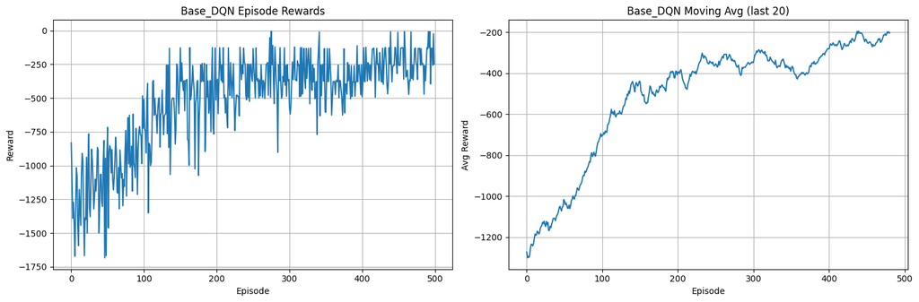

```python
# Plot results
plot_training_progress(rewards_base, model_name="Base_DQN")
```

```python
# Test the agent
test_rewards_base = test_agent(agent_base, episodes=10, render=False)
```

```
[Base_DQN] Test Episode 0: Reward = -116.47
[Base_DQN] Test Episode 1: Reward = -127.18
[Base_DQN] Test Episode 2: Reward = -129.71
[Base_DQN] Test Episode 3: Reward = -249.17
[Base_DQN] Test Episode 4: Reward = -126.01
[Base_DQN] Test Episode 5: Reward = -126.22
[Base_DQN] Test Episode 6: Reward = -255.28
[Base_DQN] Test Episode 7: Reward = -120.62
[Base_DQN] Test Episode 8: Reward = -126.70
[Base_DQN] Test Episode 9: Reward = -363.20

[Base_DQN] Average Test Reward: -174.06 ± 80.74
```

```python
# Collect metrics
model_results.append({
    "Model": "Base_DQN",
    "final_train_reward": rewards_base[-1],
    "avg_last20_train_reward": np.mean(rewards_base[-20:]),
    "best_train_reward": np.max(rewards_base),
    "worst_train_reward": np.min(rewards_base),
    "mean_test_reward": np.mean(test_rewards_base),
    "std_test_reward": np.std(test_rewards_base),
    "best_test_reward": np.max(test_rewards_base),
    "worst_test_reward": np.min(test_rewards_base),
})
```

```python
agent_base.model.save_weights('Base_DQN.weights.h5')
print('Saved')
```

```
Saved
```

## Double DQN

```python
# Create and train the agent
agent_double = DoubleDQNPendulum(model_name="Double_DQN")
rewards_double = train_dqn_agent(agent_double, episodes=500)
```

```
[Double_DQN] GPU available: []
[Double_DQN] Ep 000 | Reward:  -881.98 | Avg:  -881.98 | Epsilon: 0.9950
[Double_DQN] Ep 020 | Reward: -1439.69 | Avg: -1244.56 | Epsilon: 0.9001
[Double_DQN] Ep 040 | Reward: -1221.00 | Avg: -1263.92 | Epsilon: 0.8142
[Double_DQN] Ep 060 | Reward: -1065.20 | Avg: -1178.38 | Epsilon: 0.7366
[Double_DQN] Ep 080 | Reward:  -972.54 | Avg: -1015.64 | Epsilon: 0.6663
[Double_DQN] Ep 100 | Reward:  -374.22 | Avg:  -811.16 | Epsilon: 0.6027
[Double_DQN] Ep 120 | Reward:  -499.91 | Avg:  -698.22 | Epsilon: 0.5452
[Double_DQN] Ep 140 | Reward:  -376.17 | Avg:  -724.46 | Epsilon: 0.4932
[Double_DQN] Ep 160 | Reward:  -619.48 | Avg:  -578.39 | Epsilon: 0.4462
[Double_DQN] Ep 180 | Reward:  -498.94 | Avg:  -544.85 | Epsilon: 0.4036
[Double_DQN] Ep 200 | Reward:  -734.27 | Avg:  -592.56 | Epsilon: 0.3651
[Double_DQN] Ep 220 | Reward:  -608.57 | Avg:  -588.42 | Epsilon: 0.3303
[Double_DQN] Ep 240 | Reward:  -620.32 | Avg:  -598.58 | Epsilon: 0.2988
[Double_DQN] Ep 260 | Reward:  -634.30 | Avg:  -595.78 | Epsilon: 0.2703
[Double_DQN] Ep 280 | Reward:  -732.17 | Avg:  -637.01 | Epsilon: 0.2445
[Double_DQN] Ep 300 | Reward:  -401.32 | Avg:  -554.74 | Epsilon: 0.2212
[Double_DQN] Ep 320 | Reward:  -505.17 | Avg:  -477.21 | Epsilon: 0.2001
[Double_DQN] Ep 340 | Reward:  -383.70 | Avg:  -502.10 | Epsilon: 0.1810
[Double_DQN] Ep 360 | Reward:  -636.96 | Avg:  -530.29 | Epsilon: 0.1637
[Double_DQN] Ep 380 | Reward:  -385.48 | Avg:  -597.25 | Epsilon: 0.1481
[Double_DQN] Ep 400 | Reward:  -510.20 | Avg:  -504.01 | Epsilon: 0.1340
[Double_DQN] Ep 420 | Reward:  -386.67 | Avg:  -506.97 | Epsilon: 0.1212
[Double_DQN] Ep 440 | Reward:  -374.77 | Avg:  -366.80 | Epsilon: 0.1096
[Double_DQN] Ep 460 | Reward:  -255.55 | Avg:  -338.37 | Epsilon: 0.0992
[Double_DQN] Ep 480 | Reward:  -252.10 | Avg:  -357.65 | Epsilon: 0.0897
```

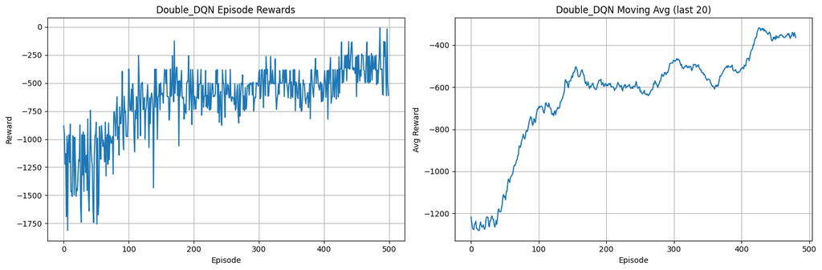

```python
# Plot results
plot_training_progress(rewards_double, model_name="Double_DQN")
```

```python
# Test the agent
test_rewards_double = test_agent(agent_double, episodes=10, render=False)
```

```
[Double_DQN] Test Episode 0: Reward = -368.99
[Double_DQN] Test Episode 1: Reward = -141.06
[Double_DQN] Test Episode 2: Reward = -141.00
[Double_DQN] Test Episode 3: Reward = -16.43
[Double_DQN] Test Episode 4: Reward = -137.71
[Double_DQN] Test Episode 5: Reward = -240.38
[Double_DQN] Test Episode 6: Reward = -17.41
[Double_DQN] Test Episode 7: Reward = -140.41
[Double_DQN] Test Episode 8: Reward = -139.81
[Double_DQN] Test Episode 9: Reward = -141.76

[Double_DQN] Average Test Reward: -148.50 ± 95.97
```

```python
# Collect metrics
model_results.append({
    "Model": "Double_DQN",
    "final_train_reward": rewards_double[-1],
    "avg_last20_train_reward": np.mean(rewards_double[-20:]),
    "best_train_reward": np.max(rewards_double),
    "worst_train_reward": np.min(rewards_double),
    "mean_test_reward": np.mean(test_rewards_double),
    "std_test_reward": np.std(test_rewards_double),
    "best_test_reward": np.max(test_rewards_double),
    "worst_test_reward": np.min(test_rewards_double),
})
```

```python
agent_double.model.save_weights('Double_DQN.weights.h5')
print('Saved')
```

```
Saved
```

## Dueling DQN

```python
# Create and train the agent
agent_dueling = DuelingDQNPendulum(model_name="Dueling_DQN")
rewards_dueling = train_dqn_agent(agent_dueling, episodes=500)
```

```
[Dueling_DQN] GPU available: []
[Dueling_DQN] Ep 000 | Reward: -1069.73 | Avg: -1069.73 | Epsilon: 0.9950
[Dueling_DQN] Ep 020 | Reward:  -891.25 | Avg: -1151.80 | Epsilon: 0.9001
[Dueling_DQN] Ep 040 | Reward: -1059.65 | Avg: -1265.95 | Epsilon: 0.8142
[Dueling_DQN] Ep 060 | Reward:  -767.01 | Avg: -1114.65 | Epsilon: 0.7366
[Dueling_DQN] Ep 080 | Reward: -1037.51 | Avg: -1005.22 | Epsilon: 0.6663
[Dueling_DQN] Ep 100 | Reward:  -522.68 | Avg:  -709.77 | Epsilon: 0.6027
[Dueling_DQN] Ep 120 | Reward:  -625.53 | Avg:  -823.33 | Epsilon: 0.5452
[Dueling_DQN] Ep 140 | Reward:  -379.89 | Avg:  -599.11 | Epsilon: 0.4932
[Dueling_DQN] Ep 160 | Reward:  -377.50 | Avg:  -530.10 | Epsilon: 0.4462
[Dueling_DQN] Ep 180 | Reward:  -494.26 | Avg:  -604.93 | Epsilon: 0.4036
[Dueling_DQN] Ep 200 | Reward:  -743.56 | Avg:  -595.84 | Epsilon: 0.3651
[Dueling_DQN] Ep 220 | Reward:  -503.01 | Avg:  -580.08 | Epsilon: 0.3303
[Dueling_DQN] Ep 240 | Reward:  -511.60 | Avg:  -610.87 | Epsilon: 0.2988
[Dueling_DQN] Ep 260 | Reward:  -513.69 | Avg:  -565.04 | Epsilon: 0.2703
[Dueling_DQN] Ep 280 | Reward:  -603.29 | Avg:  -565.86 | Epsilon: 0.2445
[Dueling_DQN] Ep 300 | Reward:  -620.35 | Avg:  -514.49 | Epsilon: 0.2212
[Dueling_DQN] Ep 320 | Reward:  -382.30 | Avg:  -507.98 | Epsilon: 0.2001
[Dueling_DQN] Ep 340 | Reward:  -377.33 | Avg:  -495.86 | Epsilon: 0.1810
[Dueling_DQN] Ep 360 | Reward:  -382.31 | Avg:  -422.87 | Epsilon: 0.1637
[Dueling_DQN] Ep 380 | Reward:  -711.71 | Avg:  -478.01 | Epsilon: 0.1481
[Dueling_DQN] Ep 400 | Reward:  -258.39 | Avg:  -456.47 | Epsilon: 0.1340
[Dueling_DQN] Ep 420 | Reward:  -575.13 | Avg:  -455.48 | Epsilon: 0.1212
[Dueling_DQN] Ep 440 | Reward:  -525.40 | Avg:  -404.63 | Epsilon: 0.1096
[Dueling_DQN] Ep 460 | Reward:  -261.61 | Avg:  -299.64 | Epsilon: 0.0992
[Dueling_DQN] Ep 480 | Reward:  -377.08 | Avg:  -409.68 | Epsilon: 0.0897
```

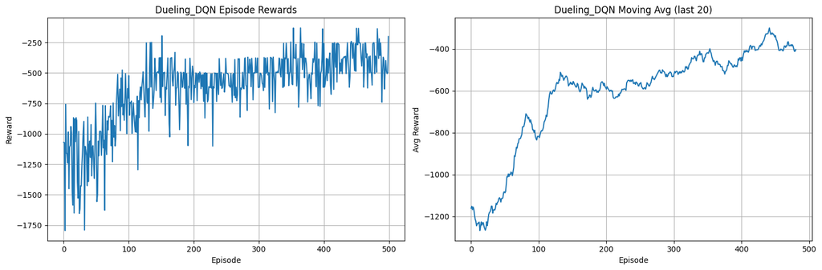

```python
# Plot results
plot_training_progress(rewards_dueling, model_name="Dueling_DQN")
```

```python
# Test the agent
test_rewards_dueling = test_agent(agent_dueling, episodes=10, render=False)
```

```
[Dueling_DQN] Test Episode 0: Reward = -230.63
[Dueling_DQN] Test Episode 1: Reward = -129.78
[Dueling_DQN] Test Episode 2: Reward = -126.19
[Dueling_DQN] Test Episode 3: Reward = -228.66
[Dueling_DQN] Test Episode 4: Reward = -130.77
[Dueling_DQN] Test Episode 5: Reward = -120.26
[Dueling_DQN] Test Episode 6: Reward = -122.86
[Dueling_DQN] Test Episode 7: Reward = -5.99
[Dueling_DQN] Test Episode 8: Reward = -230.11
[Dueling_DQN] Test Episode 9: Reward = -246.75

[Dueling_DQN] Average Test Reward: -157.20 ± 71.87
```

```python
# Collect metrics
model_results.append({
    "Model": "Dueling_DQN",
    "final_train_reward": rewards_dueling[-1],
    "avg_last20_train_reward": np.mean(rewards_dueling[-20:]),
    "best_train_reward": np.max(rewards_dueling),
    "worst_train_reward": np.min(rewards_dueling),
    "mean_test_reward": np.mean(test_rewards_dueling),
    "std_test_reward": np.std(test_rewards_dueling),
    "best_test_reward": np.max(test_rewards_dueling),
    "worst_test_reward": np.min(test_rewards_dueling),
})
```

```python
agent_dueling.model.save_weights('Dueling_DQN.weights.h5')
print('Saved')
```

```
Saved
```

## PER DQN

```python
# Create and train the agent
agent_per = PERDQNPendulum()
rewards_per = train_dqn_agent(agent_per, episodes=500)
```

[output not shown]

```
[PER_DQN] GPU available: []
[PER_DQN] Ep 000 | Reward: -1375.34 | Avg: -1375.34 | Epsilon: 0.9950
[PER_DQN] Ep 020 | Reward: -1320.02 | Avg: -1202.46 | Epsilon: 0.9001
[PER_DQN] Ep 040 | Reward: -1378.01 | Avg: -1213.01 | Epsilon: 0.8142
[PER_DQN] Ep 060 | Reward:  -895.11 | Avg: -1252.08 | Epsilon: 0.7366
[PER_DQN] Ep 080 | Reward:  -767.12 | Avg: -1027.88 | Epsilon: 0.6663
[PER_DQN] Ep 100 | Reward:  -997.27 | Avg:  -975.05 | Epsilon: 0.6027
[PER_DQN] Ep 120 | Reward:  -971.55 | Avg:  -866.90 | Epsilon: 0.5452
[PER_DQN] Ep 140 | Reward:  -239.01 | Avg:  -731.10 | Epsilon: 0.4932
[PER_DQN] Ep 160 | Reward:  -498.46 | Avg:  -638.71 | Epsilon: 0.4462
[PER_DQN] Ep 180 | Reward:  -372.94 | Avg:  -363.40 | Epsilon: 0.4036
[PER_DQN] Ep 200 | Reward:  -127.60 | Avg:  -322.37 | Epsilon: 0.3651
[PER_DQN] Ep 220 | Reward:  -897.82 | Avg:  -493.63 | Epsilon: 0.3303
[PER_DQN] Ep 240 | Reward:  -481.07 | Avg:  -291.80 | Epsilon: 0.2988
[PER_DQN] Ep 260 | Reward:  -125.15 | Avg:  -272.00 | Epsilon: 0.2703
[PER_DQN] Ep 280 | Reward:  -358.89 | Avg:  -301.28 | Epsilon: 0.2445
[PER_DQN] Ep 300 | Reward:  -235.09 | Avg:  -270.87 | Epsilon: 0.2212
[PER_DQN] Ep 320 | Reward:  -254.16 | Avg:  -216.90 | Epsilon: 0.2001
[PER_DQN] Ep 340 | Reward:  -252.91 | Avg:  -229.34 | Epsilon: 0.1810
[PER_DQN] Ep 360 | Reward:  -253.02 | Avg:  -195.01 | Epsilon: 0.1637
[PER_DQN] Ep 380 | Reward:  -123.22 | Avg:  -169.46 | Epsilon: 0.1481
[PER_DQN] Ep 400 | Reward:  -257.17 | Avg:  -313.14 | Epsilon: 0.1340
[PER_DQN] Ep 420 | Reward:  -488.34 | Avg:  -283.69 | Epsilon: 0.1212
[PER_DQN] Ep 440 | Reward:  -250.66 | Avg:  -273.70 | Epsilon: 0.1096
[PER_DQN] Ep 460 | Reward:  -375.65 | Avg:  -260.98 | Epsilon: 0.0992
[PER_DQN] Ep 480 | Reward:  -374.16 | Avg:  -364.23 | Epsilon: 0.0897
```

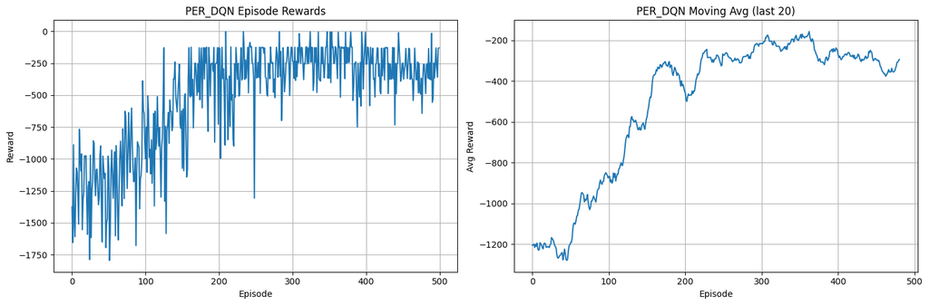

```python
# Plot results
plot_training_progress(rewards_per, model_name="PER_DQN")
```

```python
# Test the agent
test_rewards_per = test_agent(agent_per, episodes=10, render=False)
```

```
[PER_DQN] Test Episode 0: Reward = -391.89
[PER_DQN] Test Episode 1: Reward = -10.67
[PER_DQN] Test Episode 2: Reward = -127.56
[PER_DQN] Test Episode 3: Reward = -132.79
[PER_DQN] Test Episode 4: Reward = -129.77
[PER_DQN] Test Episode 5: Reward = -135.64
[PER_DQN] Test Episode 6: Reward = -129.69
[PER_DQN] Test Episode 7: Reward = -573.71
[PER_DQN] Test Episode 8: Reward = -244.95
[PER_DQN] Test Episode 9: Reward = -267.91

[PER_DQN] Average Test Reward: -214.46 ± 155.13
```

```python
# Collect metrics
model_results.append({
    "Model": "PER_DQN",
    "final_train_reward": rewards_per[-1],
    "avg_last20_train_reward": np.mean(rewards_per[-20:]),
    "best_train_reward": np.max(rewards_per),
    "worst_train_reward": np.min(rewards_per),
    "mean_test_reward": np.mean(test_rewards_per),
    "std_test_reward": np.std(test_rewards_per),
    "best_test_reward": np.max(test_rewards_per),
    "worst_test_reward": np.min(test_rewards_per),
})
```

```python
agent_per.model.save_weights('PER_DQN.weights.h5')
print('Saved')
```

```
Saved
```

## MiniRainbow DQN

```python
# Create and train the agent
agent_rainbow = MiniRainbowDQNPendulum()
rewards_rainbow = train_dqn_agent(agent_rainbow, episodes=500)
```

```
[Mini_Rainbow_DQN] GPU available: []
[Mini_Rainbow_DQN] Ep 000 | Reward: -1047.91 | Avg: -1047.91 | Epsilon: 0.9950
[Mini_Rainbow_DQN] Ep 020 | Reward: -1603.23 | Avg: -1322.33 | Epsilon: 0.9001
[Mini_Rainbow_DQN] Ep 040 | Reward: -1531.81 | Avg: -1282.48 | Epsilon: 0.8142
[Mini_Rainbow_DQN] Ep 060 | Reward: -1107.40 | Avg: -1181.30 | Epsilon: 0.7366
[Mini_Rainbow_DQN] Ep 080 | Reward: -1187.88 | Avg: -1252.39 | Epsilon: 0.6663
[Mini_Rainbow_DQN] Ep 100 | Reward:  -860.92 | Avg: -1026.90 | Epsilon: 0.6027
[Mini_Rainbow_DQN] Ep 120 | Reward:  -973.85 | Avg:  -860.33 | Epsilon: 0.5452
[Mini_Rainbow_DQN] Ep 140 | Reward: -1478.05 | Avg:  -833.85 | Epsilon: 0.4932
[Mini_Rainbow_DQN] Ep 160 | Reward:  -714.85 | Avg:  -634.35 | Epsilon: 0.4462
[Mini_Rainbow_DQN] Ep 180 | Reward:  -629.26 | Avg:  -625.00 | Epsilon: 0.4036
[Mini_Rainbow_DQN] Ep 200 | Reward:  -674.47 | Avg:  -488.64 | Epsilon: 0.3651
[Mini_Rainbow_DQN] Ep 220 | Reward: -1472.23 | Avg:  -428.32 | Epsilon: 0.3303
[Mini_Rainbow_DQN] Ep 240 | Reward:  -220.61 | Avg:  -329.91 | Epsilon: 0.2988
[Mini_Rainbow_DQN] Ep 260 | Reward:  -124.50 | Avg:  -301.52 | Epsilon: 0.2703
[Mini_Rainbow_DQN] Ep 280 | Reward:  -129.17 | Avg:  -428.55 | Epsilon: 0.2445
[Mini_Rainbow_DQN] Ep 300 | Reward:  -109.15 | Avg:  -346.83 | Epsilon: 0.2212
[Mini_Rainbow_DQN] Ep 320 | Reward:    -4.18 | Avg:  -377.13 | Epsilon: 0.2001
[Mini_Rainbow_DQN] Ep 340 | Reward:  -248.35 | Avg:  -341.70 | Epsilon: 0.1810
[Mini_Rainbow_DQN] Ep 360 | Reward:  -124.79 | Avg:  -395.02 | Epsilon: 0.1637
[Mini_Rainbow_DQN] Ep 380 | Reward:  -239.34 | Avg:  -259.52 | Epsilon: 0.1481
[Mini_Rainbow_DQN] Ep 400 | Reward:  -123.42 | Avg:  -219.24 | Epsilon: 0.1340
[Mini_Rainbow_DQN] Ep 420 | Reward:  -130.01 | Avg:  -225.40 | Epsilon: 0.1212
[Mini_Rainbow_DQN] Ep 440 | Reward:  -131.91 | Avg:  -352.38 | Epsilon: 0.1096
[Mini_Rainbow_DQN] Ep 460 | Reward:  -132.06 | Avg:  -304.48 | Epsilon: 0.0992
[Mini_Rainbow_DQN] Ep 480 | Reward:  -365.19 | Avg:  -184.32 | Epsilon: 0.0897
```

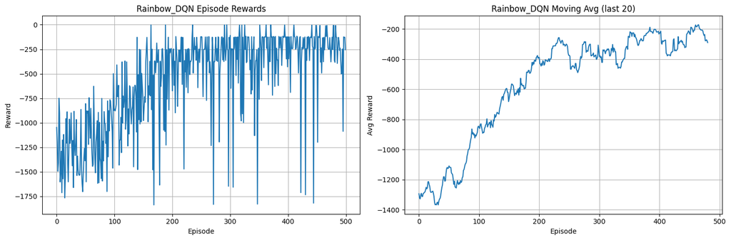

```python
# Plot results
plot_training_progress(rewards_rainbow, model_name="Rainbow_DQN")
```

```python
# Test the agent
test_rewards_rainbow = test_agent(agent_rainbow, episodes=10, render=False)
```

```
[Mini_Rainbow_DQN] Test Episode 0: Reward = -386.39
[Mini_Rainbow_DQN] Test Episode 1: Reward = -254.39
[Mini_Rainbow_DQN] Test Episode 2: Reward = -128.21
[Mini_Rainbow_DQN] Test Episode 3: Reward = -264.51
[Mini_Rainbow_DQN] Test Episode 4: Reward = -131.40
[Mini_Rainbow_DQN] Test Episode 5: Reward = -130.59
[Mini_Rainbow_DQN] Test Episode 6: Reward = -403.98
[Mini_Rainbow_DQN] Test Episode 7: Reward = -367.52
[Mini_Rainbow_DQN] Test Episode 8: Reward = -127.39
[Mini_Rainbow_DQN] Test Episode 9: Reward = -127.89

[Mini_Rainbow_DQN] Average Test Reward: -232.22 ± 112.38
```

```python
# Collect metrics
model_results.append({
    "Model": "Rainbow_DQN",
    "final_train_reward": rewards_rainbow[-1],
    "avg_last20_train_reward": np.mean(rewards_rainbow[-20:]),
    "best_train_reward": np.max(rewards_rainbow),
    "worst_train_reward": np.min(rewards_rainbow),
    "mean_test_reward": np.mean(test_rewards_rainbow),
    "std_test_reward": np.std(test_rewards_rainbow),
    "best_test_reward": np.max(test_rewards_rainbow),
    "worst_test_reward": np.min(test_rewards_rainbow),
})
```

```python
agent_rainbow.model.save_weights('Rainbow_DQN.weights.h5')
print('Saved')
```

```
Saved
```

# Model Evaluation

We implemented several DQN variants such as:

- **Base DQN**
- **Double DQN**
- **Dueling DQN**
- **Prioritized Experience Replay DQN**
- **Mini Rainbow DQN**

We define the best setup as one that achieves:

- **Stable learning**: Low variance in reward over time
- **High average reward**: Close to the theoretical maximum of 0
- **Fast convergence**: Fewer episodes to reach steady performance

We monitor:

- **20-episode** moving average reward
- **Best average** reward over training
- **Test Performance** the average test reward of an agent over 10 episodes

```python
def highlight_rl_metrics(df):
    processed_df = df.copy()

    higher_is_better = [
        'final_train_reward',
        'avg_last20_train_reward',
        'best_train_reward',
        'mean_test_reward',
        'best_test_reward',
        'worst_train_reward',
        'worst_test_reward'
    ]
    lower_is_better = [
        'std_test_reward'
    ]

    def style_column(series):
        if series.name in higher_is_better:
            best = series.max()
            worst = series.min()
        elif series.name in lower_is_better:
            best = series.min()
            worst = series.max()
        else:
            return ['' for _ in series]

        return [
            'background-color: lightgreen' if val == best else
            'background-color: lightcoral' if val == worst else ''
            for val in series
        ]

    return processed_df.style.apply(style_column, subset=higher_is_better + lower_is_better)
```

**Why we evaluate on these metrics**

**final_train_reward:**

- We record the reward from the final training episode to see the agent's most recent performance and whether it has converged.

**avg_last20_train_reward:**

- Averaging the last 20 episodes gives a smoother signal of recent learning trends and reduces noise from a single episode's randomness.

**best_train_reward / worst_train_reward:**

- These give us the range of performance during training — helpful to assess stability and volatility over time.

**mean_test_reward:**

- We evaluate the agent in test mode (usually with epsilon = 0) to measure its true learned behavior without exploration. The average tells us how well the agent performs overall.

**std_test_reward:**

- Standard deviation captures consistency across multiple test episodes. A high value may indicate instability in learned policy.

**best_test_reward / worst_test_reward:**

- These highlight the peak and weakest performance during evaluation, offering insights into best-case vs worst-case behavior.

```python
df_results = pd.DataFrame(model_results)
styled_results = highlight_rl_metrics(df_results)
styled_results
```

|  | Model | final_train_reward | avg_last20_train_reward | best_train_reward | worst_train_reward | mean_test_reward | std_test_reward | best_test_reward | worst_test_reward |
| --- | --- | --- | --- | --- | --- | --- | --- | --- | --- |
| 0 | Base_DQN | -249.850915 | -204.763219 | -5.473145 | -1683.732894 | -174.056402 | 80.739754 | -116.471692 | -363.198862 |
| 1 | Double_DQN | -609.853721 | -364.653926 | -8.595856 | -1814.096408 | -148.498644 | 95.967674 | -16.432330 | -368.991942 |
| 2 | Dueling_DQN | -201.774419 | -402.790196 | -131.066805 | -1794.025693 | -157.201108 | 71.870647 | -5.994045 | -246.746733 |
| 3 | PER_DQN | -129.243366 | -293.773559 | -1.091997 | -1794.429709 | -214.458132 | 155.129409 | -10.672755 | -573.712574 |
| 4 | Rainbow_DQN | -255.060322 | -289.490655 | -1.101219 | -1838.413531 | -232.224914 | 112.380783 | -127.388350 | -403.977767 |

# Model Improvement

```python
import keras_tuner as kt

class DuelingDQNTuner(DuelingDQNPendulum):
    def __init__(self, hp):
        # Pass through to base class
        super().__init__(model_name="Tuner_Dueling")

        # Tune hyperparameters
        self.hidden_sizes = (
            hp.Choice("hidden1", [64, 128]),
            hp.Choice("hidden2", [64, 128]),
        )
        self.lr = hp.Choice("learning_rate", [1e-3, 1e-4])
        self.epsilon_decay = hp.Choice("epsilon_decay", [0.995, 0.9995])
        self.epsilon_min = hp.Choice("epsilon_min", [0.01, 0.05, 0.1])
        self.gamma = hp.Choice("gamma", [0.95, 0.98, 0.99])
        self.n_actions = hp.Choice("n_actions", [5, 7, 9, 11, 13])
        self.batch_size = hp.Choice("batch_size", [32, 64, 128])
        self.target_update_freq = hp.Choice("target_update_freq", [500, 1000, 2000])

        # Recompute discrete actions
        self.discrete_actions = np.linspace(
            self.env.action_space.low[0],
            self.env.action_space.high[0],
            self.n_actions,
            dtype=np.float32,
        )
        self.model = self._build_model()
        self.target_model = self._build_model()
        self.update_target_network()
```

**Hyperparameter Tuning with Keras Tuner**

To systematically explore and improve our Dueling DQN model, we used Keras Tuner to perform automated hyperparameter search. This allows us to identify combinations of settings that yield higher test rewards and more stable training.

We extended our `DuelingDQNPendulum` agent into a `DuelingDQNTuner` class that accepts hyperparameters from the tuning framework.

**Why Tune Hyperparameters?**

Different configurations of neural network and training parameters can significantly affect:

- Learning stability
- Convergence speed
- Final performance

Manual tuning is inefficient and often suboptimal. By automating the process, we allow the tuner to explore a broader space of possibilities.

**What Hyperparameters Can You Tune?**

- These choices reflect common best practices for DQN tuning while keeping the search space manageable.

[output not shown]

**Is one trial enough, or should you repeat the trials?**

**One trial is not enough**. In the context of hyperparameter tuning, especially when **using methods like Bayesian Optimization**, **each trial tests a different combination of hyperparameters** in search of better performance. In our case, **we ran 30 trials using Keras Tuner**, where each trial represents a **unique set of hyperparameters** chosen based on the results of previous trials.

We **chose Bayesian Optimization** because it's **more efficient than grid or random search**. Instead of exhaustively or randomly testing combinations, it builds **a probabilistic model** that focuses the search on regions of the **hyperparameter space that are more promising**. This makes it especially effective when compute resources are limited, as a smaller number of trials can still yield strong results.

Running 30 trials gave us a **balanced approach**: it explored a wide enough range of combinations without becoming too time-consuming. Overall, we're confident that this method helped us **find a well-optimized setup for our model.**

```python
class DQNHyperModel(kt.HyperModel):
    def build(self, hp):
        # Create and return the DQN agent
        agent = DuelingDQNTuner(hp)
        return agent.model  # Return the Keras model, not the agent

    def fit(self, hp, model, *args, **kwargs):
        # Create agent with the model
        agent = DuelingDQNTuner(hp)
        agent.model = model

        # Train the agent
        train_dqn_agent(agent, episodes=50)

        # Test and return the score
        test_rewards = test_agent(agent, episodes=5)
        return np.mean(test_rewards)
```

**Tuning Setup and Scoring**

We created a custom HyperModel class, DQNHyperModel, which defines both the build and fit steps for Keras Tuner

- In build(), the model is constructed using the sampled hyperparameters.
- In fit(), the agent is trained for 50 episodes and evaluated over 5 test episodes.
- The mean test reward is returned as the tuning objective.

**This allows Keras Tuner to:**

- Try different configurations.
- Train and evaluate each configuration.
- Rank them based on test performance.

```python
# Use the HyperModel with tuner
hypermodel = DQNHyperModel()

tuner = kt.BayesianOptimization(
    hypermodel,
    objective=kt.Objective("score", direction="max"),
    max_trials=30,
    directory="dueling_dqn_tuner",
    project_name="pendulum_tuning"
)
```

```
[Tuner_Dueling] GPU available: []
```

[output not shown]

```python
tuner.search()
```

```
Trial 30 Complete [00h 00m 49s]
score: -357.0542763800833

Best score So Far: -77.85236400375267
Total elapsed time: 00h 25m 15s
```

```python
tuner.results_summary()
```

```
Results summary
Results in dueling_dqn_tuner/pendulum_tuning
Showing 10 best trials
Objective(name="score", direction="max")

Trial 07 summary
Hyperparameters:
hidden1: 128
hidden2: 64
learning_rate: 0.0001
epsilon_decay: 0.9995
epsilon_min: 0.01
gamma: 0.99
n_actions: 9
batch_size: 32
target_update_freq: 500
Score: -77.85236400375267

Trial 26 summary
Hyperparameters:
hidden1: 64
hidden2: 128
learning_rate: 0.0001
epsilon_decay: 0.995
epsilon_min: 0.01
gamma: 0.95
n_actions: 5
batch_size: 32
target_update_freq: 500
Score: -99.82595437184158

Trial 11 summary
Hyperparameters:
hidden1: 64
hidden2: 128
learning_rate: 0.001
epsilon_decay: 0.995
epsilon_min: 0.05
gamma: 0.95
n_actions: 7
```

[output cut: 79 more lines]

```
target_update_freq: 500
Score: -514.4149379077675

Trial 06 summary
Hyperparameters:
hidden1: 128
hidden2: 128
learning_rate: 0.0001
epsilon_decay: 0.9995
epsilon_min: 0.1
gamma: 0.99
n_actions: 13
batch_size: 32
target_update_freq: 1000
Score: -591.7879632715234
```

```python
# Get best hyperparameters
best_hp = tuner.get_best_hyperparameters(num_trials=1)[0]

# Print them out
print("✅ Best hyperparameters found:")
print(f"Learning rate:        {best_hp.get('learning_rate')}")
print(f"Gamma:                {best_hp.get('gamma')}")
print(f"Epsilon decay:        {best_hp.get('epsilon_decay')}")
print(f"Epsilon min:          {best_hp.get('epsilon_min')}")
print(f"Number of actions:    {best_hp.get('n_actions')}")
print(f"Hidden layer 1 size:  {best_hp.get('hidden1')}")
print(f"Hidden layer 2 size:  {best_hp.get('hidden2')}")
print(f"Batch size:           {best_hp.get('batch_size')}")
print(f"Target update freq:   {best_hp.get('target_update_freq')}")
```

```
✅ Best hyperparameters found:
Learning rate:        0.0001
Gamma:                0.99
Epsilon decay:        0.9995
Epsilon min:          0.01
Number of actions:    9
Hidden layer 1 size:  128
Hidden layer 2 size:  64
Batch size:           32
Target update freq:   500
```

```python
import json

# Get best trial's hyperparameters
best_hp = tuner.get_best_hyperparameters(1)[0]

# Convert to dictionary
best_hp_dict = {
    "learning_rate": best_hp.get("learning_rate"),
    "gamma": best_hp.get("gamma"),
    "epsilon_decay": best_hp.get("epsilon_decay"),
    "epsilon_min": best_hp.get("epsilon_min"),
    "n_actions": best_hp.get("n_actions"),
    "hidden1": best_hp.get("hidden1"),
    "hidden2": best_hp.get("hidden2"),
    "batch_size": best_hp.get("batch_size"),
    "target_update_freq": best_hp.get("target_update_freq")
}

# Save to JSON file
with open("best_hyperparameters.json", "w") as f:
    json.dump(best_hp_dict, f, indent=4)

print("✅ Best hyperparameters saved to best_hyperparameters.json")
```

```
✅ Best hyperparameters saved to best_hyperparameters.json
```

# Training Best Model

```python
# Set up the Agent
best_agent = DuelingDQNPendulum(model_name="Best_Dueling")

# Set the best hyperparameters
best_agent.hidden_sizes = (
    best_hp.get("hidden1"),
    best_hp.get("hidden2")
)
best_agent.lr = best_hp.get("learning_rate")
best_agent.gamma = best_hp.get("gamma")
best_agent.epsilon_decay = best_hp.get("epsilon_decay")
best_agent.epsilon_min = best_hp.get("epsilon_min")
best_agent.n_actions = best_hp.get("n_actions")
best_agent.batch_size = best_hp.get("batch_size")
best_agent.target_update_freq = best_hp.get("target_update_freq")

# Recompute discrete action space
best_agent.discrete_actions = np.linspace(
    best_agent.env.action_space.low[0],
    best_agent.env.action_space.high[0],
    best_agent.n_actions,
    dtype=np.float32,
)

# Rebuild the model with new hyperparams
best_agent.model = best_agent._build_model()
best_agent.target_model = best_agent._build_model()
best_agent.update_target_network()
```

```
[Best_Dueling] GPU available: []
```

```python
best_agent.model.summary()
```

```
Model: "functional_18"
```

```
┏━━━━━━━━━━━━━━━━━━━━━┳━━━━━━━━━━━━━━━━━━━┳━━━━━━━━━━━━┳━━━━━━━━━━━━━━━━━━━┓
┃ Layer (type)        ┃ Output Shape      ┃    Param # ┃ Connected to      ┃
┡━━━━━━━━━━━━━━━━━━━━━╇━━━━━━━━━━━━━━━━━━━╇━━━━━━━━━━━━╇━━━━━━━━━━━━━━━━━━━┩
│ input_layer_18      │ (None, 3)         │          0 │ -                 │
│ (InputLayer)        │                   │            │                   │
├─────────────────────┼───────────────────┼────────────┼───────────────────┤
│ dense_72 (Dense)    │ (None, 128)       │        512 │ input_layer_18[0… │
├─────────────────────┼───────────────────┼────────────┼───────────────────┤
│ dense_73 (Dense)    │ (None, 64)        │      8,256 │ dense_72[0][0]    │
├─────────────────────┼───────────────────┼────────────┼───────────────────┤
│ dense_75 (Dense)    │ (None, 9)         │        585 │ dense_73[0][0]    │
├─────────────────────┼───────────────────┼────────────┼───────────────────┤
│ lambda_18 (Lambda)  │ (None, 1)         │          0 │ dense_75[0][0]    │
├─────────────────────┼───────────────────┼────────────┼───────────────────┤
│ dense_74 (Dense)    │ (None, 1)         │         65 │ dense_73[0][0]    │
├─────────────────────┼───────────────────┼────────────┼───────────────────┤
│ subtract_18         │ (None, 9)         │          0 │ dense_75[0][0],   │
│ (Subtract)          │                   │            │ lambda_18[0][0]   │
├─────────────────────┼───────────────────┼────────────┼───────────────────┤
│ add_18 (Add)        │ (None, 9)         │          0 │ dense_74[0][0],   │
│                     │                   │            │ subtract_18[0][0] │
└─────────────────────┴───────────────────┴────────────┴───────────────────┘
```

```
 Total params: 9,418 (36.79 KB)
```

```
 Trainable params: 9,418 (36.79 KB)
```

```
 Non-trainable params: 0 (0.00 B)
```

```python
# Train the agent for 1000 episodes
rewards_best = train_dqn_agent(best_agent, episodes=1000)
```

```
[Best_Dueling] Ep 000 | Reward:  -891.42 | Avg:  -891.42 | Epsilon: 0.9995
[Best_Dueling] Ep 020 | Reward:  -873.51 | Avg: -1091.95 | Epsilon: 0.9896
[Best_Dueling] Ep 040 | Reward: -1067.24 | Avg: -1271.42 | Epsilon: 0.9797
[Best_Dueling] Ep 060 | Reward:  -880.92 | Avg: -1133.76 | Epsilon: 0.9700
[Best_Dueling] Ep 080 | Reward:  -868.37 | Avg: -1136.88 | Epsilon: 0.9603
[Best_Dueling] Ep 100 | Reward: -1438.61 | Avg: -1155.32 | Epsilon: 0.9507
[Best_Dueling] Ep 120 | Reward: -1071.21 | Avg: -1147.95 | Epsilon: 0.9413
[Best_Dueling] Ep 140 | Reward:  -951.96 | Avg: -1126.70 | Epsilon: 0.9319
[Best_Dueling] Ep 160 | Reward:  -958.77 | Avg: -1095.92 | Epsilon: 0.9226
[Best_Dueling] Ep 180 | Reward: -1320.18 | Avg: -1084.40 | Epsilon: 0.9135
[Best_Dueling] Ep 200 | Reward: -1180.45 | Avg: -1016.28 | Epsilon: 0.9044
[Best_Dueling] Ep 220 | Reward: -1306.84 | Avg: -1008.32 | Epsilon: 0.8954
[Best_Dueling] Ep 240 | Reward: -1491.77 | Avg: -1046.09 | Epsilon: 0.8865
[Best_Dueling] Ep 260 | Reward: -1389.78 | Avg: -1098.80 | Epsilon: 0.8776
[Best_Dueling] Ep 280 | Reward: -1072.75 | Avg: -1041.51 | Epsilon: 0.8689
[Best_Dueling] Ep 300 | Reward:  -853.42 | Avg: -1019.99 | Epsilon: 0.8602
[Best_Dueling] Ep 320 | Reward: -1339.02 | Avg:  -934.52 | Epsilon: 0.8517
[Best_Dueling] Ep 340 | Reward:  -857.90 | Avg: -1059.19 | Epsilon: 0.8432
[Best_Dueling] Ep 360 | Reward:  -870.65 | Avg:  -981.36 | Epsilon: 0.8348
[Best_Dueling] Ep 380 | Reward:  -872.82 | Avg: -1047.41 | Epsilon: 0.8265
[Best_Dueling] Ep 400 | Reward: -1171.95 | Avg: -1104.99 | Epsilon: 0.8183
[Best_Dueling] Ep 420 | Reward:  -850.36 | Avg:  -929.51 | Epsilon: 0.8101
[Best_Dueling] Ep 440 | Reward:  -992.09 | Avg: -1011.02 | Epsilon: 0.8021
[Best_Dueling] Ep 460 | Reward:  -979.15 | Avg:  -942.22 | Epsilon: 0.7941
[Best_Dueling] Ep 480 | Reward: -1220.14 | Avg: -1013.53 | Epsilon: 0.7862
[Best_Dueling] Ep 500 | Reward:  -755.16 | Avg:  -985.63 | Epsilon: 0.7784
[Best_Dueling] Ep 520 | Reward: -1092.88 | Avg:  -957.44 | Epsilon: 0.7706
[Best_Dueling] Ep 540 | Reward:  -776.87 | Avg:  -924.77 | Epsilon: 0.7629
[Best_Dueling] Ep 560 | Reward:  -757.35 | Avg:  -856.46 | Epsilon: 0.7554
[Best_Dueling] Ep 580 | Reward: -1175.61 | Avg:  -903.18 | Epsilon: 0.7478
[Best_Dueling] Ep 600 | Reward:  -818.75 | Avg:  -969.01 | Epsilon: 0.7404
[Best_Dueling] Ep 620 | Reward:  -644.12 | Avg:  -766.59 | Epsilon: 0.7330
[Best_Dueling] Ep 640 | Reward:  -506.58 | Avg:  -820.97 | Epsilon: 0.7257
[Best_Dueling] Ep 660 | Reward:  -849.29 | Avg:  -891.91 | Epsilon: 0.7185
[Best_Dueling] Ep 680 | Reward:  -741.40 | Avg:  -920.59 | Epsilon: 0.7114
[Best_Dueling] Ep 700 | Reward:  -853.45 | Avg:  -922.49 | Epsilon: 0.7043
[Best_Dueling] Ep 720 | Reward:  -751.81 | Avg:  -859.43 | Epsilon: 0.6973
[Best_Dueling] Ep 740 | Reward:  -628.82 | Avg:  -800.02 | Epsilon: 0.6903
[Best_Dueling] Ep 760 | Reward:  -750.78 | Avg:  -861.53 | Epsilon: 0.6835
[Best_Dueling] Ep 780 | Reward: -1107.92 | Avg:  -895.54 | Epsilon: 0.6767
[Best_Dueling] Ep 800 | Reward: -1077.64 | Avg:  -858.09 | Epsilon: 0.6699
[Best_Dueling] Ep 820 | Reward:  -506.69 | Avg:  -810.68 | Epsilon: 0.6633
[Best_Dueling] Ep 840 | Reward:  -952.23 | Avg:  -888.25 | Epsilon: 0.6566
[Best_Dueling] Ep 860 | Reward:  -984.43 | Avg:  -865.93 | Epsilon: 0.6501
[Best_Dueling] Ep 880 | Reward:  -625.01 | Avg:  -786.08 | Epsilon: 0.6436
[Best_Dueling] Ep 900 | Reward:  -499.67 | Avg:  -743.26 | Epsilon: 0.6372
[Best_Dueling] Ep 920 | Reward:  -742.46 | Avg:  -736.00 | Epsilon: 0.6309
[Best_Dueling] Ep 940 | Reward:  -752.20 | Avg:  -775.18 | Epsilon: 0.6246
[Best_Dueling] Ep 960 | Reward:  -878.38 | Avg:  -758.77 | Epsilon: 0.6184
[Best_Dueling] Ep 980 | Reward:  -979.31 | Avg:  -779.56 | Epsilon: 0.6122
```

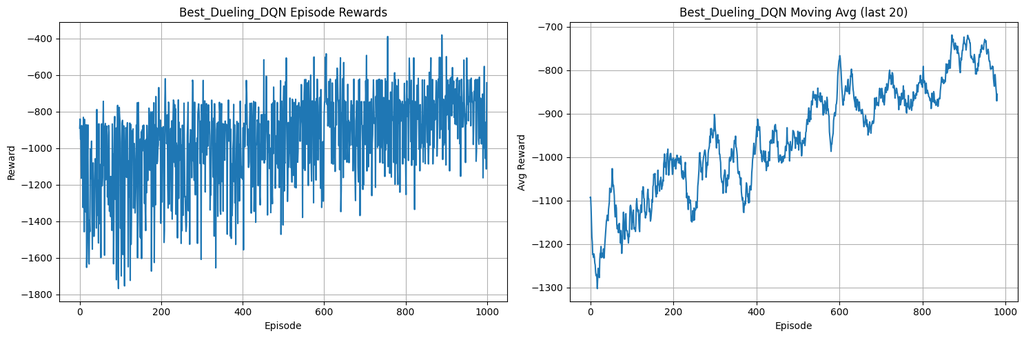

```python
# Plot results
plot_training_progress(rewards_best, model_name="Best_Dueling_DQN")
```

```python
# Test the agent
test_rewards_best = test_agent(best_agent, episodes=10, render=False)
```

```
[Best_Dueling] Test Episode 0: Reward = -124.47
[Best_Dueling] Test Episode 1: Reward = -119.95
[Best_Dueling] Test Episode 2: Reward = -8.23
[Best_Dueling] Test Episode 3: Reward = -124.08
[Best_Dueling] Test Episode 4: Reward = -250.03
[Best_Dueling] Test Episode 5: Reward = -2.27
[Best_Dueling] Test Episode 6: Reward = -125.23
[Best_Dueling] Test Episode 7: Reward = -117.31
[Best_Dueling] Test Episode 8: Reward = -2.16
[Best_Dueling] Test Episode 9: Reward = -2.93

[Best_Dueling] Average Test Reward: -87.67 ± 77.76
```

```python
best_agent.model.save_weights("Best_Dueling_DQN.weights.h5")
print('Saved')
```

```
Saved
```

```python
# ⚙️ ENV + AGENT SETUP
import gym
from gym.wrappers import Monitor

# Create and wrap environment for video recording
env = gym.make("Pendulum-v0")
env = Monitor(env, "./videos", force=True)

# Set agent's environment to monitored env
agent = best_agent
agent.env = env  # only if not already set
```

```python
# Test the agent
test_rewards_best = test_agent(best_agent, episodes=1, render=True)
```

```
[Best_Dueling] Test Episode 0: Reward = -6.57

[Best_Dueling] Average Test Reward: -6.57 ± 0.00
```

```python
# 📽️ DISPLAY VIDEO IN KAGGLE
from IPython.display import HTML
from base64 import b64encode

# Find the .mp4 video created by Monitor
mp4_path = None
for root, _, files in os.walk("./videos/"):
    for file in files:
        if file.endswith(".mp4"):
            mp4_path = os.path.join(root, file)
            break

# Show video inline
if mp4_path:
    video = open(mp4_path, "rb").read()
    b64 = b64encode(video).decode()
    display(HTML(f"""
    <video width=600 controls>
        <source src="data:video/mp4;base64,{b64}" type="video/mp4">
    </video>
    """))
else:
    print("No video found.")
```

[video not shown]

# Conclusion